# Reproducible Research: Peer Assessment 1

This document describes some basic analysis of “exercise” data (in terms of number of steps taken per 5-minute interval, over a number of different days).

The data were obtained from Roger Peng’s [github](https://github.com/rdpeng/RepData_PeerAssessment1) site as the file “activity.zip”, which is then decompressed to produce the input file “activity.csv”. The data can also be obtained directly from here.

## Loading and preprocessing the data

Use the `read.csv()` method from R to straightforwardly read the data into a `data.frame` called `activity`:

```r
activity <- read.csv("activity.csv")
```

The data contains a number of `NA` fields, however as long as we are aware of this there is no need to pre-process the data any further.

```r
sapply(activity, function(x) length(which(is.na(x))))
```

```
##    steps     date interval
##     2304        0        0
```

## What is mean total number of steps taken per day?

Once in a `data.frame`, it is straightforward to calculate the number of steps taken per day using `tapply()` with the function `sum`, using the `na.rm = TRUE` argument, and simply taking the mean of the resultant vector

```r
stepsByDay <- tapply(activity$steps, activity$date, sum, na.rm = TRUE)
stepsByDay
```

```
## 2012-10-01 2012-10-02 2012-10-03 2012-10-04 2012-10-05 2012-10-06
##          0        126      11352      12116      13294      15420
## 2012-10-07 2012-10-08 2012-10-09 2012-10-10 2012-10-11 2012-10-12
##      11015          0      12811       9900      10304      17382
## 2012-10-13 2012-10-14 2012-10-15 2012-10-16 2012-10-17 2012-10-18
##      12426      15098      10139      15084      13452      10056
## 2012-10-19 2012-10-20 2012-10-21 2012-10-22 2012-10-23 2012-10-24
##      11829      10395       8821      13460       8918       8355
## 2012-10-25 2012-10-26 2012-10-27 2012-10-28 2012-10-29 2012-10-30
##       2492       6778      10119      11458       5018       9819
## 2012-10-31 2012-11-01 2012-11-02 2012-11-03 2012-11-04 2012-11-05
##      15414          0      10600      10571          0      10439
## 2012-11-06 2012-11-07 2012-11-08 2012-11-09 2012-11-10 2012-11-11
##       8334      12883       3219          0          0      12608
## 2012-11-12 2012-11-13 2012-11-14 2012-11-15 2012-11-16 2012-11-17
##      10765       7336          0         41       5441      14339
## 2012-11-18 2012-11-19 2012-11-20 2012-11-21 2012-11-22 2012-11-23
##      15110       8841       4472      12787      20427      21194
## 2012-11-24 2012-11-25 2012-11-26 2012-11-27 2012-11-28 2012-11-29
##      14478      11834      11162      13646      10183       7047
## 2012-11-30
##          0
```

```r
                 # The mode, i.e. 'type' of data in R! (not statistical mode)
mode(stepsByDay) # showing that tapply produces a numeric vector in this case
```

```
## [1] "numeric"
```

```r
mean(stepsByDay)
```

```
## [1] 9354.23
```

```r
median(stepsByDay)
```

```
## [1] 10395
```

The distribution of “steps per day” is best visualized as a histogram

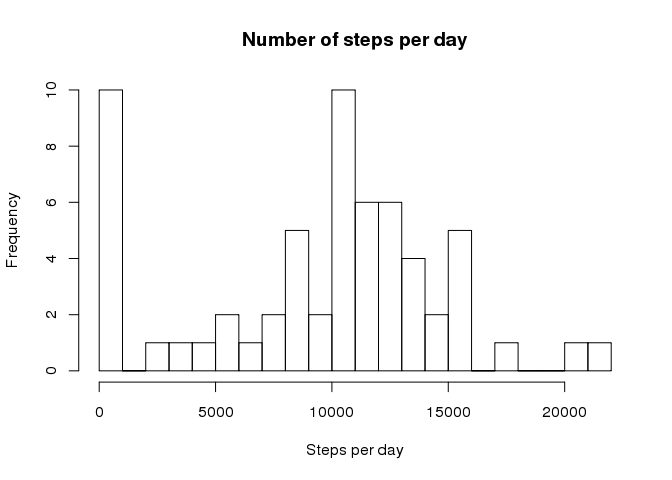

```r
hist(stepsByDay, main = "Number of steps per day", xlab = "Steps per day",
     breaks = 30)
```

## What is the average daily activity pattern?

Similarly, using `tapply()`, but this time taking the mean across time intervals (rather than sum across days), we can plot the average number of steps for each time interval throughout the day:

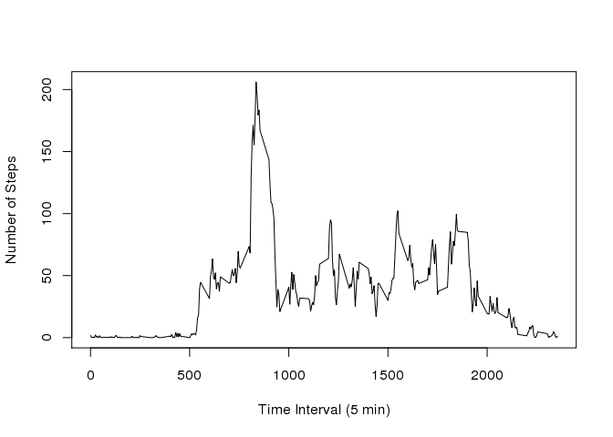

```r
stepsByTime <- tapply(activity$steps, activity$interval, mean, na.rm = TRUE)
plot(names(stepsByTime), stepsByTime, type = "l",
     xlab = "Time Interval (5 min)", ylab = "Number of Steps")
```

Visually inspecting this plot, it appears that the maximum number of steps taken for any 5-minute interval occurs around time interval number 800.

We can determine this exactly:

```r
stepsByTime[which(stepsByTime == max(stepsByTime))]
```

```
##      835
## 206.1698
```

which shows that the maximum number of steps (on average) occurs during time interval number 835.

## Imputing missing values

Having calculated the mean number of steps for each time interval throughout the day, it seems reasonable to use this value (for each time interval) to impute missing values.

```r
for(day in levels(activity$date)) {
    ind <- which(activity$date == day)
    activity$steps[ind] <-
        ifelse(is.na(activity$steps[ind]), stepsByTime, activity$steps[ind])
}
```

One can check the effect of imputing the missing data by looking at the histogram again:

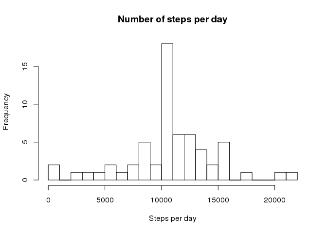

```r
hist(tapply(activity$steps, activity$date, sum),
     main = "Number of steps per day", xlab = "Steps per day",
     breaks = 30)
```

It is clear that imputing missing values reduces the number of days with “no” steps (number of steps = 0). Unfortunately this method of imputation also creates a spike at number of steps per day approximately 10,000 where all the days with no data (that were zero steps per day) get the “average” value.

## Are there differences in activity patterns between weekdays and weekends?

Using the `xyplot` function (`lattice` package), with appropriate values for the `panel` and `prepanel` functions:

```r
library(lattice)
```

Character vector element of activity for weekend/weekday

```r
activity$dayType <-
    ifelse(weekdays(as.Date(activity$date)) %in% c("Saturday","Sunday"),
           "weekend", "weekday")
```

Convert to factor for use in lattice plots

```r
activity$dayType <- as.factor(activity$dayType)
```

Pre-panel function ensures that the y-limits are set correctly

```r
myPrepan <- function(x,y) {
    y <- tapply(y, x, mean)
    list(xlim = c(min(x), max(x)),
         ylim = c(min(y),max(y)))
}
```

Panel function does a line plot of the mean (for weekend/weekday)

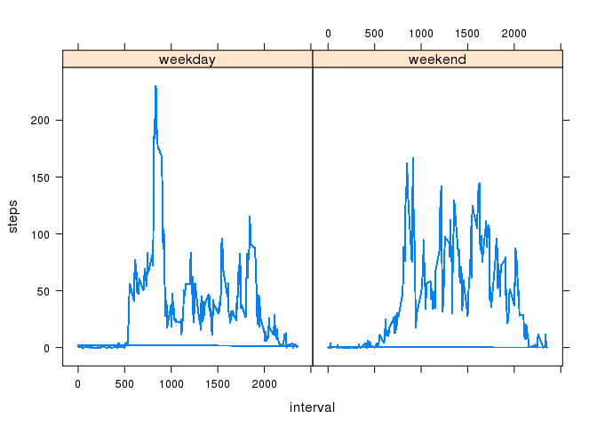

```r
myPanel <- function(x,y) llines(x = x, y = tapply(y, x, mean))

xyplot(steps ~ interval | dayType, data = activity,
       panel = myPanel, prepanel = myPrepan)
```